# Multi-omics Analysis Workflow with MultiAssayExperiment: ‘Comprehensive Pan-Genomic Characterization of Adrenocortical Carcinoma’

## A demonstration of data management and analysis of multiple biological assays.

We begin by loading the necessary libraries.

```r
library(MultiAssayExperiment)
library(GenomicRanges)
library(RaggedExperiment)
library(curatedTCGAData)
library(GenomicDataCommons)
library(SummarizedExperiment)
library(SingleCellExperiment)
library(TCGAutils)
library(UpSetR)
library(mirbase.db)
library(AnnotationFilter)
library(EnsDb.Hsapiens.v86)
library(survival)
library(survminer)
```

```r
library(pheatmap)
```

The TCGA dataset is provided with the MultiAssayExperiment package. There were 92 patients. All assays were NOT performed on every patient. Five assays included: 1. RNASeqGeneNorm: gene mRNA abundance by RNA-seq 2. gistict: GISTIC genomic copy number by gene 3. RPPAArray: protein abundance by Reverse Phase Protein Array 4. Mutations: non-silent somatic mutations by gene 5. miRNASeqGene: microRNA abundane by microRNA-seq We can gather this information by using R below:

```r
#import dataset
data("miniACC")
```

```r
miniACC
```

```
## A MultiAssayExperiment object of 5 listed
##  experiments with user-defined names and respective classes.
##  Containing an ExperimentList class object of length 5:
##  [1] RNASeq2GeneNorm: SummarizedExperiment with 198 rows and 79 columns
##  [2] gistict: SummarizedExperiment with 198 rows and 90 columns
##  [3] RPPAArray: SummarizedExperiment with 33 rows and 46 columns
##  [4] Mutations: matrix with 97 rows and 90 columns
##  [5] miRNASeqGene: SummarizedExperiment with 471 rows and 80 columns
## Functionality:
##  experiments() - obtain the ExperimentList instance
##  colData() - the primary/phenotype DataFrame
##  sampleMap() - the sample coordination DataFrame
##  `$`, `[`, `[[` - extract colData columns, subset, or experiment
##  *Format() - convert into a long or wide DataFrame
##  assays() - convert ExperimentList to a SimpleList of matrices
##  exportClass() - save all data to files
```

Examine the data by previewing the columns.

```r
colData(miniACC)
```

```
## DataFrame with 92 rows and 30 columns
##                 patientID years_to_birth vital_status days_to_death
##               <character>      <integer>    <integer>     <integer>
## TCGA-OR-A5J1 TCGA-OR-A5J1             58            1          1355
## TCGA-OR-A5J2 TCGA-OR-A5J2             44            1          1677
## TCGA-OR-A5J3 TCGA-OR-A5J3             23            0            NA
## TCGA-OR-A5J4 TCGA-OR-A5J4             23            1           423
## TCGA-OR-A5J5 TCGA-OR-A5J5             30            1           365
## ...                   ...            ...          ...           ...
## TCGA-PK-A5H9 TCGA-PK-A5H9             27            0            NA
## TCGA-PK-A5HA TCGA-PK-A5HA             63            0            NA
## TCGA-PK-A5HB TCGA-PK-A5HB             63            0            NA
## TCGA-PK-A5HC TCGA-PK-A5HC             44            0            NA
## TCGA-P6-A5OG TCGA-P6-A5OG             45            1           383
##              days_to_last_followup tumor_tissue_site pathologic_stage
##                          <integer>       <character>      <character>
## TCGA-OR-A5J1                    NA           adrenal         stage ii
## TCGA-OR-A5J2                    NA           adrenal         stage iv
## TCGA-OR-A5J3                  2091           adrenal        stage iii
## TCGA-OR-A5J4                    NA           adrenal         stage iv
## TCGA-OR-A5J5                    NA           adrenal        stage iii
## ...                            ...               ...              ...
## TCGA-PK-A5H9                   616           adrenal         stage ii
## TCGA-PK-A5HA                  1201           adrenal          stage i
## TCGA-PK-A5HB                  1293           adrenal               NA
## TCGA-PK-A5HC                   679           adrenal        stage iii
## TCGA-P6-A5OG                    NA           adrenal         stage iv
##              pathology_T_stage pathology_N_stage      gender
##                    <character>       <character> <character>
## TCGA-OR-A5J1                t2                n0        male
## TCGA-OR-A5J2                t3                n0      female
## TCGA-OR-A5J3                t3                n0      female
## TCGA-OR-A5J4                t3                n1      female
## TCGA-OR-A5J5                t4                n0        male
## ...                        ...               ...         ...
## TCGA-PK-A5H9                t2                n0      female
## TCGA-PK-A5HA                t1                n0        male
## TCGA-PK-A5HB                NA                NA        male
## TCGA-PK-A5HC                t4                n0      female
## TCGA-P6-A5OG                t4                n0      female
```

[output cut: 63 more lines]

```
## TCGA-PK-A5HC  Chromosomal              NA          NA    TP53/NF1      0.59
## TCGA-P6-A5OG           NA              NA          NA          NA        NA
##                 ploidy genome_doublings       ADS
##              <numeric>        <integer> <numeric>
## TCGA-OR-A5J1      1.95                0     -0.08
## TCGA-OR-A5J2      1.31                0     -0.84
## TCGA-OR-A5J3      1.25                0      1.18
## TCGA-OR-A5J4      2.60                1        NA
## TCGA-OR-A5J5      2.75                1     -1.00
## ...                ...              ...       ...
## TCGA-PK-A5H9      2.00                0     -0.85
## TCGA-PK-A5HA      1.69                0     -1.49
## TCGA-PK-A5HB      1.64                0     -0.31
## TCGA-PK-A5HC      2.53                1        NA
## TCGA-P6-A5OG        NA               NA        NA
```

We can aggregate the column names, experiments associated with the dataset, by running the following code:

```r
colnames(miniACC)
```

```
## CharacterList of length 5
## [["RNASeq2GeneNorm"]] TCGA-OR-A5J1-01A-11R-A29S-07 ...
## [["gistict"]] TCGA-OR-A5J1-01A-11D-A29H-01 ... TCGA-PK-A5HC-01A-11D-A309-01
## [["RPPAArray"]] TCGA-OR-A5J2-01A-21-A39K-20 ... TCGA-PK-A5HA-01A-21-A39K-20
## [["Mutations"]] TCGA-OR-A5J1-01A-11D-A29I-10 ... TCGA-PK-A5HC-01A-11D-A30A-10
## [["miRNASeqGene"]] TCGA-OR-A5J1-01A-11R-A29W-13 ...
```

A more compressed way to preview the data for exploratory analysis would be to preview particular columns rather than all of the columns. Below we will preview the first 4 columns and their first 4 rows.

```r
colData(miniACC)[1:4, 1:4]
```

```
## DataFrame with 4 rows and 4 columns
##                 patientID years_to_birth vital_status days_to_death
##               <character>      <integer>    <integer>     <integer>
## TCGA-OR-A5J1 TCGA-OR-A5J1             58            1          1355
## TCGA-OR-A5J2 TCGA-OR-A5J2             44            1          1677
## TCGA-OR-A5J3 TCGA-OR-A5J3             23            0            NA
## TCGA-OR-A5J4 TCGA-OR-A5J4             23            1           423
```

*It is important to omit the indexing feature from the miniACC object being called. Including the brackets within the parenthesis in the usual fashion we’d use with indexing datasets will create a much lengthier output.

We can select features we are interested in and examine them in tabular format. For example, a table is created to provide insight into the diversity of the patients involved.

```r
table(miniACC$race)
```

```
##
##                     asian black or african american                     white
##                         2                         1                        78
```

We can also create a table to determine the age range of the patients in case we want to evaluate data by age range.

```r
table(miniACC$years_to_birth)
```

```
##
## 14 17 20 22 23 25 26 27 29 30 31 32 34 36 37 39 40 42 44 45 46 47 48 49 50 51
##  1  2  1  2  4  2  2  1  1  3  1  2  1  3  4  2  1  3  3  3  1  1  2  1  1  1
## 52 53 54 55 56 57 58 59 60 61 62 63 64 65 66 67 68 69 71 72 74 75 77 83
##  3  4  1  3  1  2  2  3  2  4  1  2  1  3  1  1  1  2  1  1  1  1  1  1
```

This will also provide insights into the youngest and oldest study participants allowing us to conclude whether this dataset will be beneficial in providing the answers we seek.

Let’s look at the details of the experiments used.

```r
experiments(miniACC)
```

```
## ExperimentList class object of length 5:
##  [1] RNASeq2GeneNorm: SummarizedExperiment with 198 rows and 79 columns
##  [2] gistict: SummarizedExperiment with 198 rows and 90 columns
##  [3] RPPAArray: SummarizedExperiment with 33 rows and 46 columns
##  [4] Mutations: matrix with 97 rows and 90 columns
##  [5] miRNASeqGene: SummarizedExperiment with 471 rows and 80 columns
```

It is clear that we are dealing with a sizable and complex dataset. A sampleMap can be created in order to examine the relationship between the biological units and experimental results.

```r
sampleMap(miniACC)
```

```
## DataFrame with 385 rows and 3 columns
##               assay      primary                colname
##            <factor>  <character>            <character>
## 1   RNASeq2GeneNorm TCGA-OR-A5J1 TCGA-OR-A5J1-01A-11R..
## 2   RNASeq2GeneNorm TCGA-OR-A5J2 TCGA-OR-A5J2-01A-11R..
## 3   RNASeq2GeneNorm TCGA-OR-A5J3 TCGA-OR-A5J3-01A-11R..
## 4   RNASeq2GeneNorm TCGA-OR-A5J5 TCGA-OR-A5J5-01A-11R..
## 5   RNASeq2GeneNorm TCGA-OR-A5J6 TCGA-OR-A5J6-01A-31R..
## ...             ...          ...                    ...
## 381    miRNASeqGene TCGA-PA-A5YG TCGA-PA-A5YG-01A-11R..
## 382    miRNASeqGene TCGA-PK-A5H8 TCGA-PK-A5H8-01A-11R..
## 383    miRNASeqGene TCGA-PK-A5H9 TCGA-PK-A5H9-01A-11R..
## 384    miRNASeqGene TCGA-PK-A5HA TCGA-PK-A5HA-01A-11R..
## 385    miRNASeqGene TCGA-PK-A5HB TCGA-PK-A5HB-01A-11R..
```

```r
cat("The column titled 'colname' displays identifiers of assay results.", "\nThe assay column provides the name of the assay.", "\nThe primary column displays identifiers of patients or biological units.")
```

```
## The column titled 'colname' displays identifiers of assay results.
## The assay column provides the name of the assay.
## The primary column displays identifiers of patients or biological units.
```

Examine any metadata that corresponds with the experiment.

```r
metadata(miniACC)
```

```
## $title
## [1] "Comprehensive Pan-Genomic Characterization of Adrenocortical Carcinoma"
##
## $PMID
## [1] "27165744"
##
## $sourceURL
## [1] "http://s3.amazonaws.com/multiassayexperiments/accMAEO.rds"
##
## $RPPAfeatureDataURL
## [1] "http://genomeportal.stanford.edu/pan-tcga/show_target_selection_file?filename=Allprotein.txt"
##
## $colDataExtrasURL
## [1] "http://www.cell.com/cms/attachment/2062093088/2063584534/mmc3.xlsx"
```

Visualize how many samples have data for each assay combination.

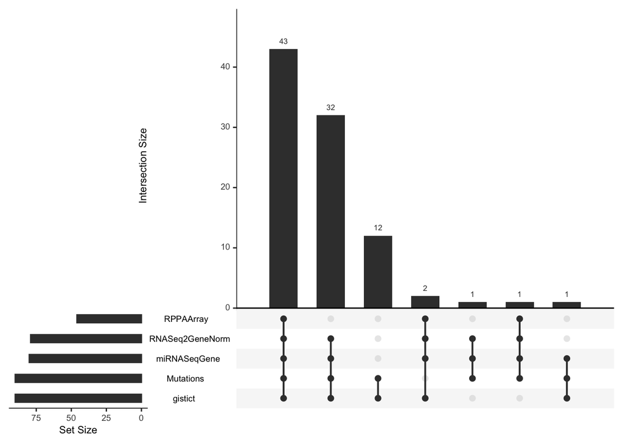

```r
upsetSamples(miniACC)
```

Interpreting the “upset” Venn diagram created above we can draw the following conclusions: 1. All 5 assays were performed on 43 patients 2. All assays except the RPPAArray (reverse-phase protein) were performed on 32 patients 3. 12 patients had only the Mutations and gistict assays *These are just a few conclusions that can be gathered from the “upset” Venn diagram.

We can visualize patient survival using a Kaplan-meier plot. Step 1: Examine the data related to survival

```r
#create survival object
Surv(miniACC$days_to_death, miniACC$vital_status)
```

```
##  [1] 1355  1677    NA+  423   365    NA+  490   579    NA+  922   551  1750
## [13]   NA+ 2105    NA+  541    NA+   NA+  490    NA+   NA+  562    NA+   NA+
## [25]   NA+   NA+   NA+   NA+  289    NA+   NA+   NA+  552    NA+   NA+   NA+
## [37]  994    NA+   NA+  498    NA+   NA+  344    NA+   NA+   NA+   NA+   NA+
## [49]   NA+   NA+   NA+   NA+   NA+  391   125    NA+ 1852    NA+   NA+   NA+
## [61]   NA+   NA+   NA+   NA+ 1204   159  1197   662   445    NA+ 2385   436
## [73] 1105    NA+ 1613    NA+   NA+ 2405    NA+   NA+   NA+   NA+   NA+  207
## [85]    0    NA+   NA+   NA+   NA+   NA+   NA+  383
```

Step 2: Remove patients that do not have survival information (NA).

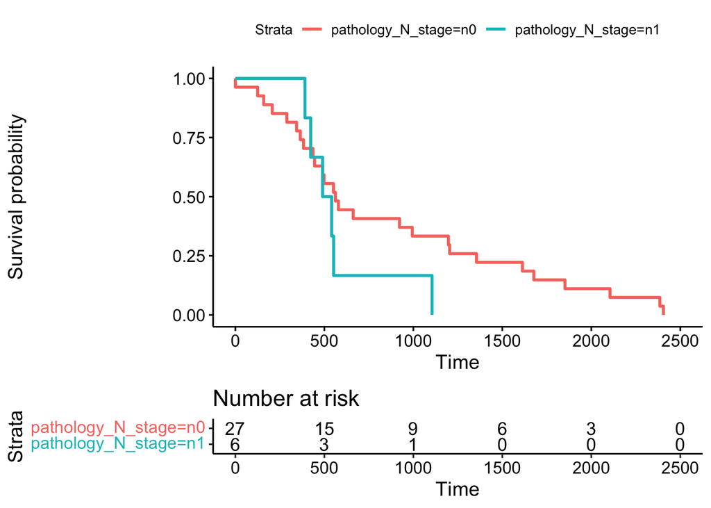

```r
#complete.cases returns a vector w/cases that are complete i.e. do not have missing values
miniACCsurviv <- miniACC[, complete.cases(miniACC$days_to_death, miniACC$vital_status), ]

#create survival curve using pathology_N_stage as the stratifying variable
kMFit <- surv_fit(Surv(days_to_death, vital_status)~ pathology_N_stage, data=colData(miniACCsurviv))

#Kaplan-meier plot
ggsurvplot(kMFit, data=colData(miniACCsurviv), risk.table = TRUE)
```

You can perform multivariate Cox Regression on the dataset using RNA-seq, copy number, and pathology.

```r
#use subsetting to drop assays that don't have the gene of interest, EZH2
wideMACC <- wideFormat(miniACC["EZH2", , ],
                       colDataCols = c("vital_status", "days_to_death", "pathology_N_stage"))
```

```
## harmonizing input:
##   removing 216 sampleMap rows not in names(experiments)
```

```r
wideMACC$y = Surv(wideMACC$days_to_death, wideMACC$vital_status)
head(wideMACC)
```

```
## DataFrame with 6 rows and 7 columns
##        primary vital_status days_to_death pathology_N_stage
##    <character>    <integer>     <integer>       <character>
## 1 TCGA-OR-A5J1            1          1355                n0
## 2 TCGA-OR-A5J2            1          1677                n0
## 3 TCGA-OR-A5J3            0            NA                n0
## 4 TCGA-OR-A5J4            1           423                n1
## 5 TCGA-OR-A5J5            1           365                n0
## 6 TCGA-OR-A5J6            0            NA                n0
##   RNASeq2GeneNorm_EZH2 gistict_EZH2      y
##              <numeric>    <numeric> <Surv>
## 1              75.8886            0 1355:1
## 2             326.5332            1 1677:1
## 3             190.1940            1   NA:0
## 4                   NA           -2  423:1
## 5             366.3826            1  365:1
## 6              30.7371            1   NA:0
```

```r
coxph(Surv(days_to_death, vital_status) ~ gistict_EZH2 + log2(RNASeq2GeneNorm_EZH2) + pathology_N_stage,
      data=wideMACC)
```

```
## Call:
## coxph(formula = Surv(days_to_death, vital_status) ~ gistict_EZH2 +
##     log2(RNASeq2GeneNorm_EZH2) + pathology_N_stage, data = wideMACC)
##
##                                coef exp(coef) se(coef)      z        p
## gistict_EZH2               -0.03723   0.96345  0.28205 -0.132 0.894986
## log2(RNASeq2GeneNorm_EZH2)  0.97731   2.65729  0.28105  3.477 0.000506
## pathology_N_stagen1         0.37749   1.45862  0.56992  0.662 0.507743
##
## Likelihood ratio test=16.28  on 3 df, p=0.0009942
## n= 26, number of events= 26
##    (66 observations deleted due to missingness)
```

```r
cat("Examination of the p-values indicates that RNASeq2GeneNormEZH2 or EZH2 expression is significantly associated with overall survival as it is the only assay with a p-value below 0.001")
```

```
## Examination of the p-values indicates that RNASeq2GeneNormEZH2 or EZH2 expression is significantly associated with overall survival as it is the only assay with a p-value below 0.001
```